# N-gram Prediction Model

suszanna

1/31/2021

### 1 Executive Summary

This report addresses an instance of an N-gram Prediction Model by using Natural Language Processing in R. It is the final project from the Coursera/Johns Hopkins course in a certification for the Data Science Specialization, the ‘Data Science Capstone Project’. The data is sourced in collaboration with Coursera and SwiftKey and can be found here: https://d396qusza40orc.cloudfront.net/dsscapstone/dataset/Coursera-SwiftKey.zip

We begin with a raw alpha-numeric textual data set and remove all but alphas, arranging them in a table or dictionary. Through a series of pre-processing steps, we continue to clean the data until it is ready to be input to the n-gram algorithm which outputs uni-grams, bi-grams and tri-grams. These predict best guess of the word that follows according to the instances within our data. Accuracy and run-time efficiency are addressed. Scripts written in R verify accuracy models against a simple data set and are included in the appendix. The outputs of each vary almost imperceptibly with each run-time and account for the variation in accuracy of tracked statistics included in each method’s header. This app is designed to run on a full sized back end server so that it can be scaled as needed in the future, as it will be open sourced for others to leverage to assist as they realize mastery in the field of data science.

### 2 Project Description

Here, we describe an N-gram prediction model with optimized performance and accuracy. We provide supporting statistics. The goal of the Prediction Model project is to create a full working model with reasonable performance & accuracy as expected by an audience of executives interested in sales. The audience is not necessarily technical, therefore technical jargon is limited. We entertain creative exploration as data science, in addition to being based in science is also an art.

Basically, the N-gram prediction model predicts the next word likely to be used in a sentence by considering the last word given, after running it’s algorithm through a large preprocessed classification data set. To implement this prediction model, on completion of the exploratory analysis, the data is cleaned and tokenized into dictionaries of words. Finally, we build the model noting accuracy of the output and efficiency in run time. Word clouds and bar-plots are provided to visualize the data sets once converted to predictive n-gram format. The appendix stresses implementations of methods for Accuracy.

### 3 Preprocess Data: load, clean, create Sample & Corpus for analysis

###### sample format of our raw data

```r
twitter[1:2]
```

```
## [1] "How are you? Btw thanks for the RT. You gonna be in DC anytime soon? Love to see you. Been way, way too long."
## [2] "When you meet someone special... you'll know. Your heart will beat more rapidly and you'll smile for no reason."
```

###### size of raw data sets

```
## [1] 899284
```

```
## [1] 1010242
```

```
## [1] 2360148
```

##### preprocessing continues - create corpus

```r
#combine samples
sample<-c(blogsSample,newsSample,twitterSample)
#length(sample)
#summary(sample)

#load sample data as corpus
corpus<-VCorpus(VectorSource(sample))
#corpus
length(corpus)
```

```
## [1] 1500
```

###### Preprocessing continues: create Term Document Matrix (TDM) from corpus & adjust sparsity index

```
## <<TermDocumentMatrix (terms: 6664, documents: 1500)>>
## Non-/sparse entries: 29352/9966648
## Sparsity           : 100%
## Maximal term length: 51
## Weighting          : term frequency (tf)
```

```
## <<TermDocumentMatrix (terms: 11, documents: 1500)>>
## Non-/sparse entries: 3645/12855
## Sparsity           : 78%
## Maximal term length: 4
## Weighting          : term frequency (tf)
```

```
## <<TermDocumentMatrix (terms: 11, documents: 1500)>>
## Non-/sparse entries: 3645/12855
## Sparsity           : 78%
## Maximal term length: 4
## Weighting          : term frequency (tf)
## Sample             :
##       Docs
## Terms  150 173 189 202 266 273 338 422 43 44
##   and    1   3   6   6   6   5   6   1  1  2
##   but    0   1   2   1   0   3   1   2  4  1
##   for    2   3   1   0   1   2   4   3  2  3
##   have   1   1   0   1   0   0   2   4  0  2
##   that   4   2   0   0   1   1   4   4  2  2
##   the   10  11   6  18  14  14  18  10 11 14
##   this   1   0   4   1   1   3   3   0  2  0
##   was    2   0   4   0   3   0   3   2  3  0
##   with   1   0   2   0   2   2   1   1  2  1
##   you   11   7   0   0   0   0   2   0  0  1
```

##### Preprocessed data is now in matrix/dictionary format as input to n-gram prediction model:

```r
head(d,10)
```

```
##      word freq
## the   the 2246
## and   and 1175
## that that  477
## for   for  472
## with with  348
## you   you  327
## was   was  265
## have have  263
## this this  240
## but   but  237
```

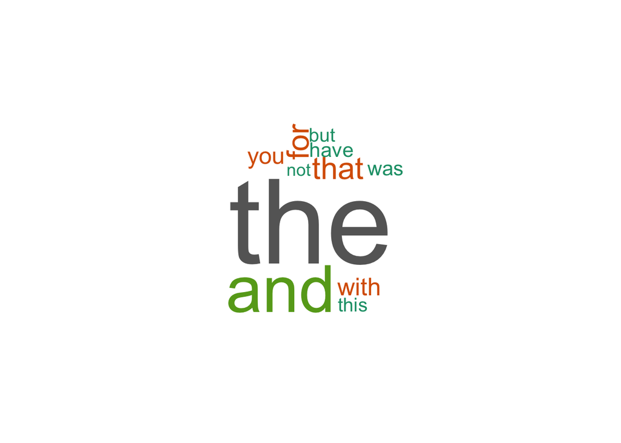

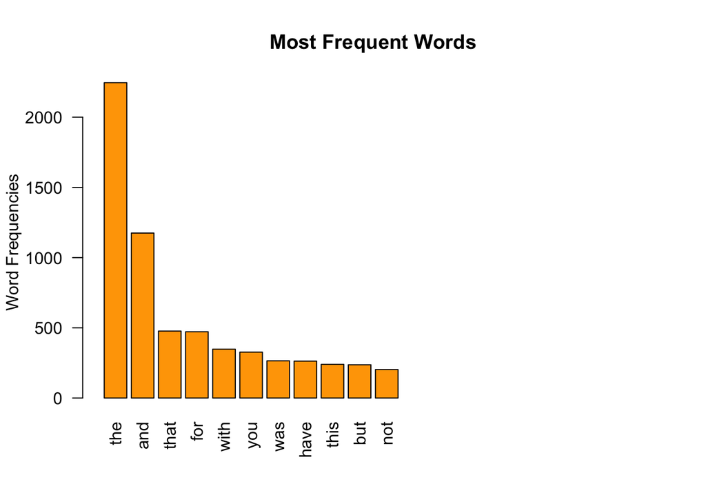

### 4 Generation & Visualization of N-gram Prediction models - predict next word

##### UNIGRAM - Tokenize and Create n-gram dataframe for unigram prediction

```
##      word1 freq
## the    the 2246
## and    and 1175
## that  that  477
## for    for  472
## with  with  348
## you    you  327
## was    was  265
## have  have  263
## this  this  240
## but    but  237
```

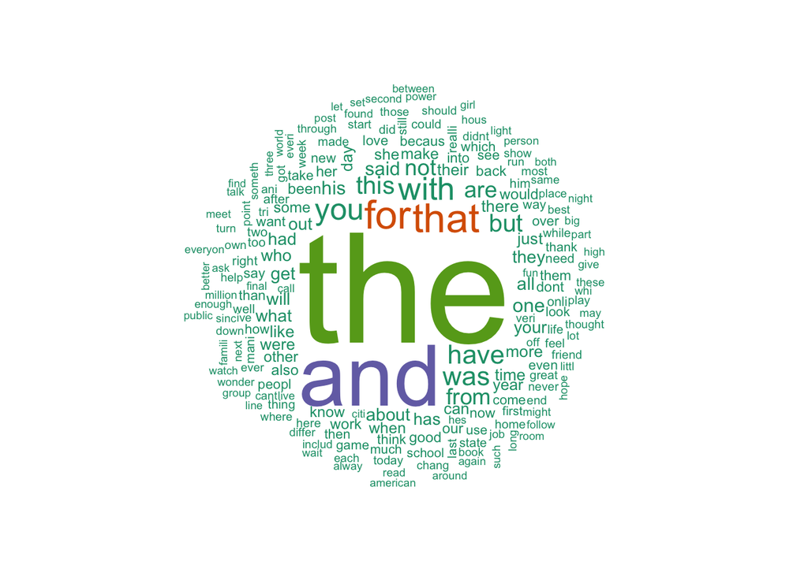

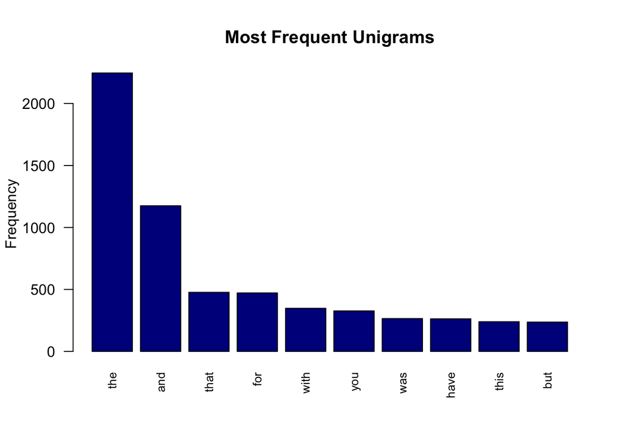

##### BIGRAM - Tokenize and Create n-gram dataframe for bigram prediction

```
##             word2 freq
## of the     of the  225
## in the     in the  185
## to the     to the  106
## for the   for the   93
## on the     on the   91
## to be       to be   79
## at the     at the   65
## and the   and the   58
## with the with the   57
## in a         in a   56
```

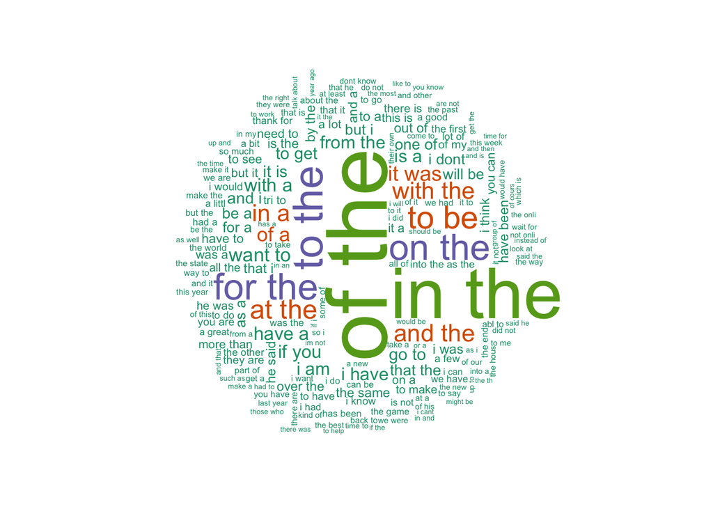

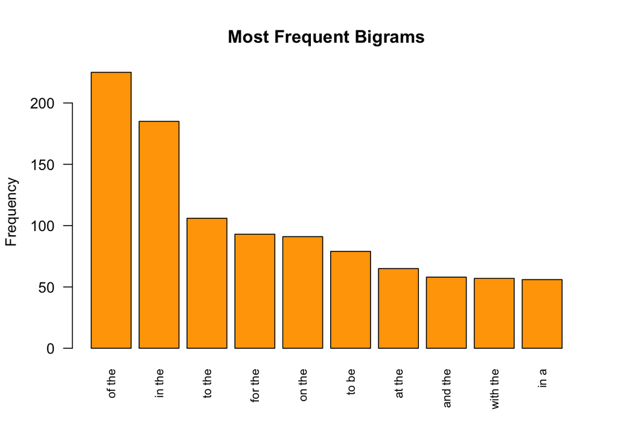

##### TRIGRAM - Tokenize and Create n-gram dataframe for trigram prediction

```
##                   word3 freq
## a lot of       a lot of   15
## one of the   one of the   15
## i have a       i have a   10
## to be a         to be a   10
## some of the some of the    9
## a coupl of   a coupl of    8
## be abl to     be abl to    8
## go to be       go to be    8
## i dont know i dont know    8
## it was the   it was the    8
```

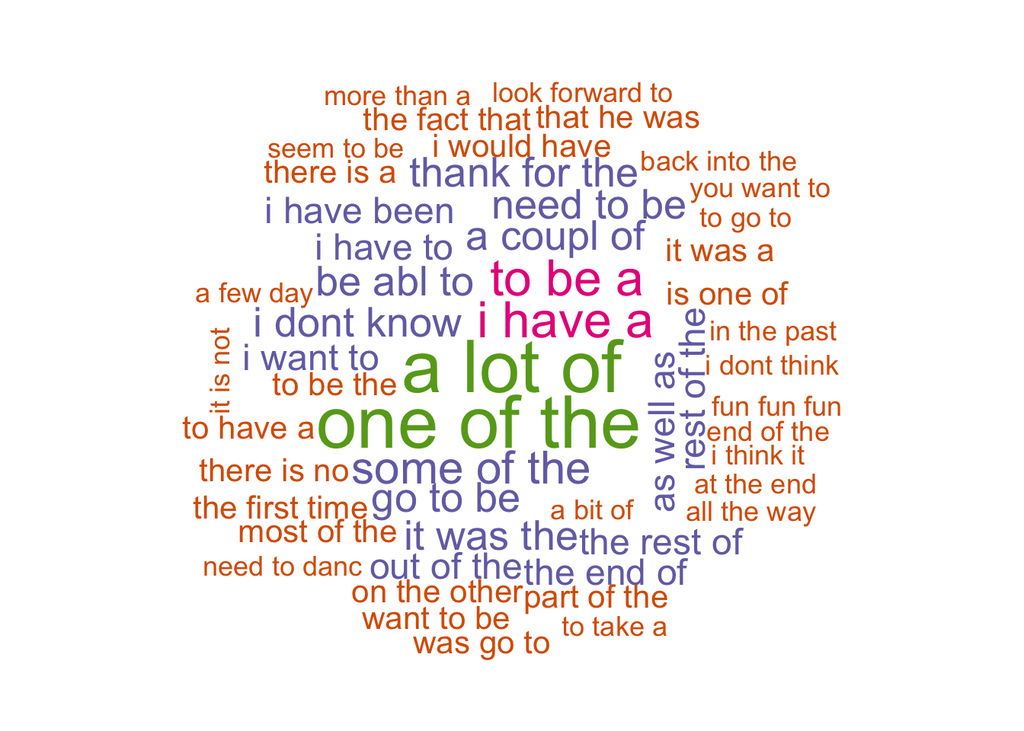

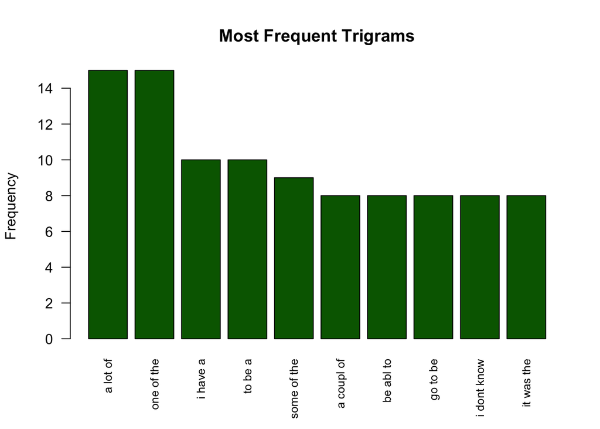

### 5 Appendix: Computational Methods for estimates in Accuracy

Below are instances of 5 different methods to estimate the n-gram model accuracy: Data Split, Bootstrap, k-fold Cross Validation, Repeated k-fold Cross Validation, and Leave One Out Cross Validation

Although these accuracy models are not exactly compatible with classification data, they are of interest when considering the application of automated accuracy models. Here, accuracy is tracked using the simple Iris data set described below. The process is to test a training sample in order to output a reliable prediction by execution of the algorithm. A well known and simple data set, the Iris data set contains 3 classes of 50 instances each, where each class refers to a type of iris plant. One class is linearly separable from the other 2; the latter are NOT linearly separable from each other. The predicted attribute is the class of iris plant.

#### Estimate Accuracy by Data Split method

Data splitting involves partitioning the data into an explicit training dataset used to prepare the model and an unseen test dataset used to evaluate the models performance on unseen data. It is useful when you have a very large dataset so that the test dataset can provide a meaningful estimation of performance, or for when you are using slow methods and need a quick approximation of performance. The example below splits the iris dataset so that 80% is used for training a Naive Bayes model and 20% is used to evaluate the models performance.

##### EXAMPLE 1: data split - returns Accuracy = 1.0, 0.933, 0.966, 0.966

```r
library(lattice)
library(caret)
library(MASS)
library(klaR)
```

```
##          1          2          4          5         22         27         29
##     setosa     setosa     setosa     setosa     setosa     setosa     setosa
##         38         44         47         54         56         57         58
##     setosa     setosa     setosa versicolor versicolor versicolor versicolor
##         63         69         73         84         86         98        101
## versicolor versicolor versicolor  virginica versicolor versicolor  virginica
##        110        113        118        129        132        134        139
##  virginica  virginica  virginica  virginica  virginica versicolor  virginica
##        145        150
##  virginica  virginica
## Levels: setosa versicolor virginica
```

```
##      1
## setosa
## Levels: setosa versicolor virginica
```

```
## Confusion Matrix and Statistics
##
##             Reference
## Prediction   setosa versicolor virginica
##   setosa         10          0         0
##   versicolor      0          9         1
##   virginica       0          1         9
##
## Overall Statistics
##
##                Accuracy : 0.9333
##                  95% CI : (0.7793, 0.9918)
##     No Information Rate : 0.3333
##     P-Value [Acc > NIR] : 8.747e-12
##
##                   Kappa : 0.9
##
##  Mcnemar's Test P-Value : NA
##
## Statistics by Class:
##
##                      Class: setosa Class: versicolor Class: virginica
## Sensitivity                 1.0000            0.9000           0.9000
## Specificity                 1.0000            0.9500           0.9500
## Pos Pred Value              1.0000            0.9000           0.9000
## Neg Pred Value              1.0000            0.9500           0.9500
## Prevalence                  0.3333            0.3333           0.3333
## Detection Rate              0.3333            0.3000           0.3000
## Detection Prevalence        0.3333            0.3333           0.3333
## Balanced Accuracy           1.0000            0.9250           0.9250
```

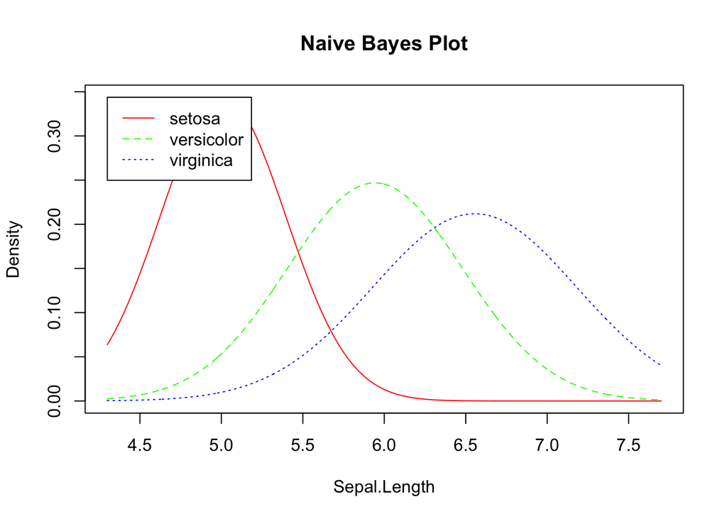

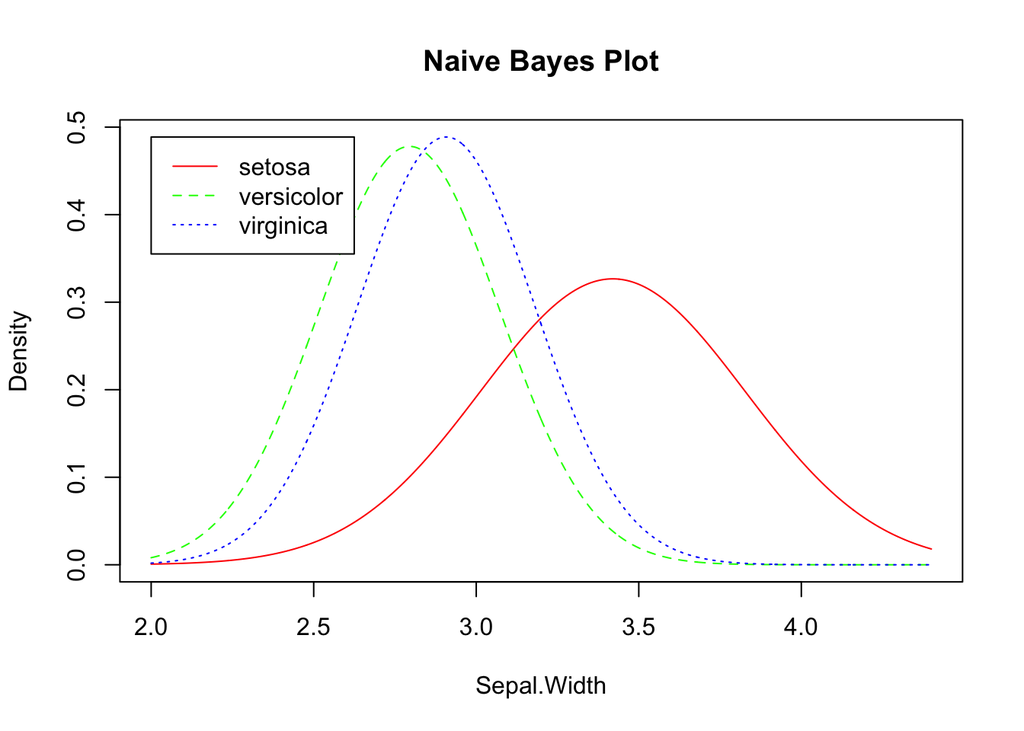

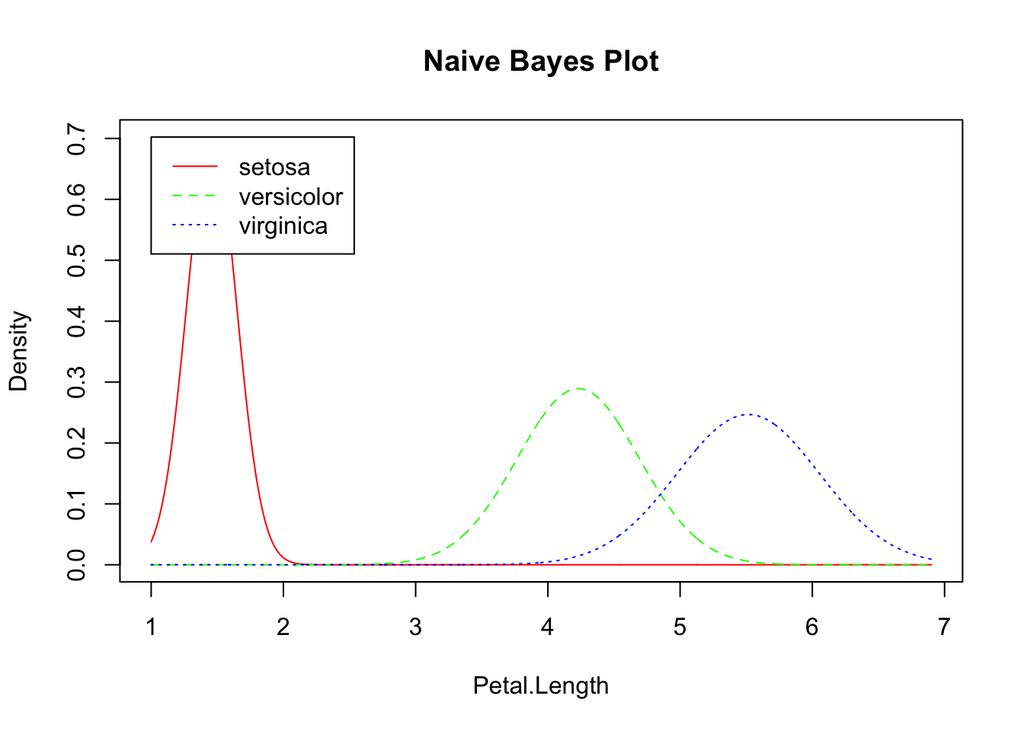

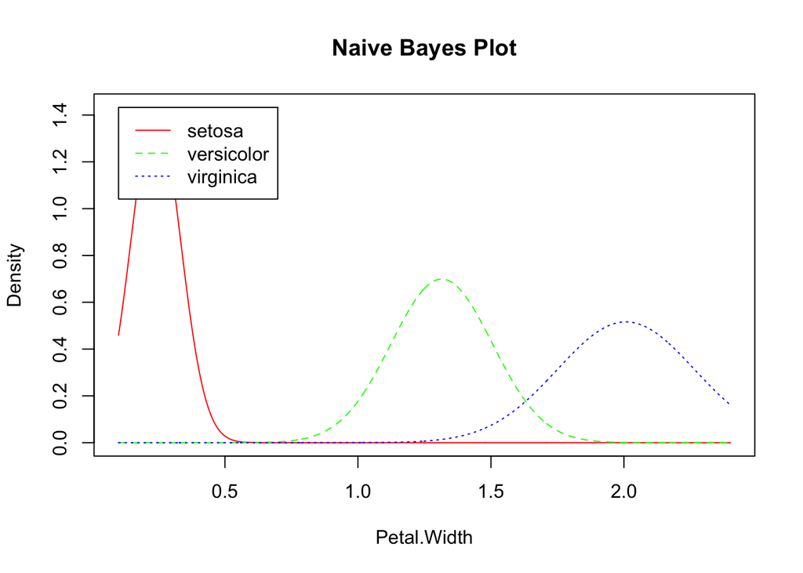

#### Estimate Accuracy by Bootstrap method

##### EXAMPLE 2: Bootstrap - returns Accuracy = 0.958, 0.953, 0.949

input: The final values used for the model were fL = 0, usekernel = TRUE and adjust = 1 output: Accuracy = 0.958, 0.953, 0.949 model: naive bayes Predicted attribute: class of iris plant

```
## Naive Bayes
##
## 150 samples
##   4 predictor
##   3 classes: 'setosa', 'versicolor', 'virginica'
##
## No pre-processing
## Resampling: Bootstrapped (100 reps)
## Summary of sample sizes: 150, 150, 150, 150, 150, 150, ...
## Resampling results across tuning parameters:
##
##   usekernel  Accuracy   Kappa
##   FALSE      0.9561497  0.9335979
##    TRUE      0.9565304  0.9341183
##
## Tuning parameter 'fL' was held constant at a value of 0
## Tuning
##  parameter 'adjust' was held constant at a value of 1
## Accuracy was used to select the optimal model using the largest value.
## The final values used for the model were fL = 0, usekernel = TRUE and adjust
##  = 1.
```

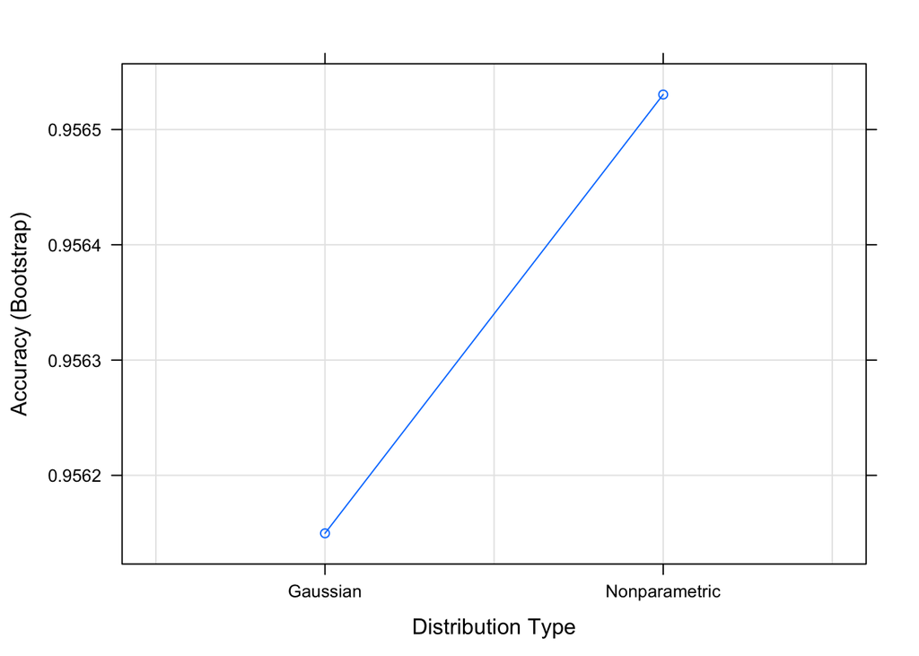

#### Estimate Accuracy by k-fold Cross Validation method

```
## [1] 5
```

```
##          1          4          6         10         14         15         19
##     setosa     setosa     setosa     setosa     setosa     setosa     setosa
##         30         41         42         53         54         62         65
##     setosa     setosa     setosa  virginica versicolor versicolor versicolor
##         71         72         78         86         90         97        101
##  virginica versicolor  virginica versicolor versicolor versicolor  virginica
##        105        108        112        114        124        125        137
##  virginica  virginica  virginica  virginica  virginica  virginica  virginica
##        140        147
##  virginica  virginica
## Levels: setosa versicolor virginica
```

```
##      1
## setosa
## Levels: setosa versicolor virginica
```

```
## Confusion Matrix and Statistics
##
##             Reference
## Prediction   setosa versicolor virginica
##   setosa         10          0         0
##   versicolor      0          7         0
##   virginica       0          3        10
##
## Overall Statistics
##
##                Accuracy : 0.9
##                  95% CI : (0.7347, 0.9789)
##     No Information Rate : 0.3333
##     P-Value [Acc > NIR] : 1.665e-10
##
##                   Kappa : 0.85
##
##  Mcnemar's Test P-Value : NA
##
## Statistics by Class:
##
##                      Class: setosa Class: versicolor Class: virginica
## Sensitivity                 1.0000            0.7000           1.0000
## Specificity                 1.0000            1.0000           0.8500
## Pos Pred Value              1.0000            1.0000           0.7692
## Neg Pred Value              1.0000            0.8696           1.0000
## Prevalence                  0.3333            0.3333           0.3333
## Detection Rate              0.3333            0.2333           0.3333
## Detection Prevalence        0.3333            0.2333           0.4333
## Balanced Accuracy           1.0000            0.8500           0.9250
```

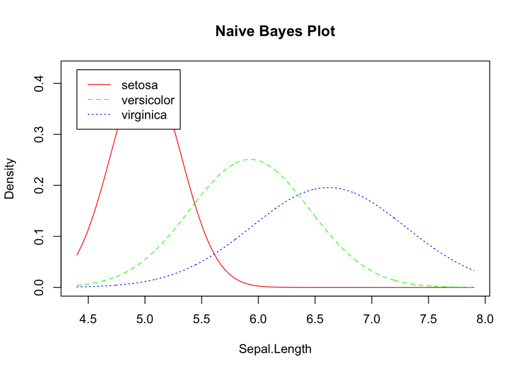

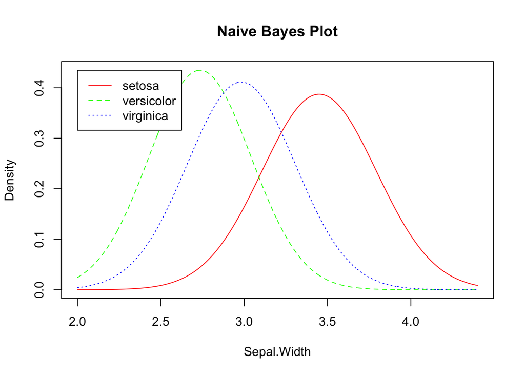

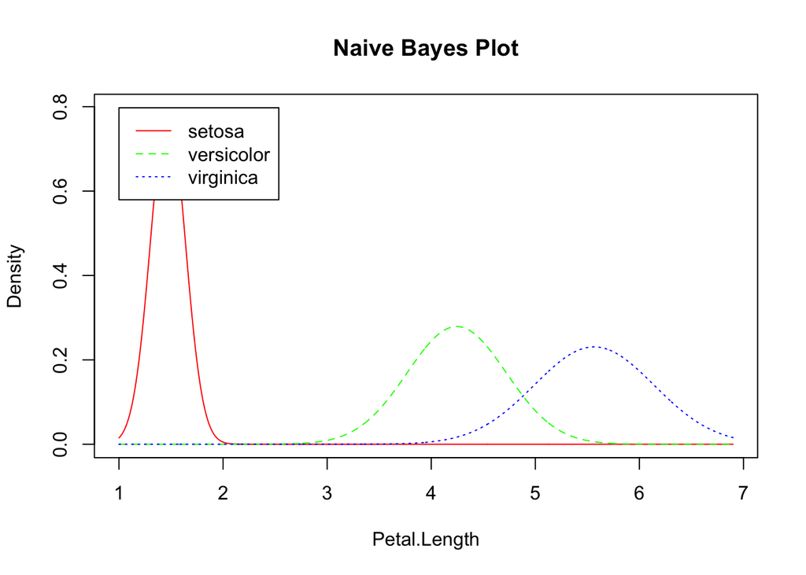

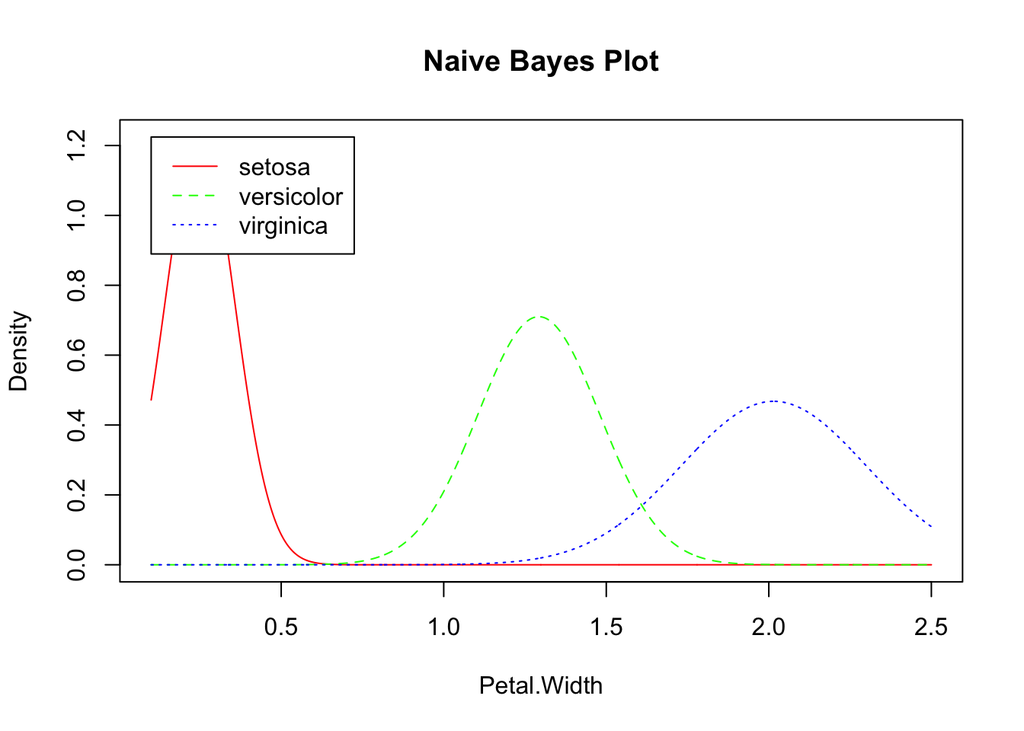

#### Estimate Accuracy by Repeated k-fold Cross Validation method

The process of splitting the data into k-folds can be repeated a number of times, this is called Repeated k-fold Cross Validation. The final model accuracy is taken as the mean from the number of repeats.The following example uses 10-fold cross validation with 3 repeats to estimate Naive Bayes on the iris dataset.

##### EXAMPLE 4: Repeated k-fold cross validation - returns accuracy 0.957, 0.955, 0.955

input: The final values used for the model were fL = 0, usekernel = TRUE and adjust = 1 output: Accuracy = 0.957, 0.955, 0.955 model: naive bayes Predicted attribute: class of iris plant

```
## Naive Bayes
##
## 150 samples
##   4 predictor
##   3 classes: 'setosa', 'versicolor', 'virginica'
##
## No pre-processing
## Resampling: Cross-Validated (10 fold, repeated 3 times)
## Summary of sample sizes: 135, 135, 135, 135, 135, 135, ...
## Resampling results across tuning parameters:
##
##   usekernel  Accuracy   Kappa
##   FALSE      0.9488889  0.9233333
##    TRUE      0.9555556  0.9333333
##
## Tuning parameter 'fL' was held constant at a value of 0
## Tuning
##  parameter 'adjust' was held constant at a value of 1
## Accuracy was used to select the optimal model using the largest value.
## The final values used for the model were fL = 0, usekernel = TRUE and adjust
##  = 1.
```

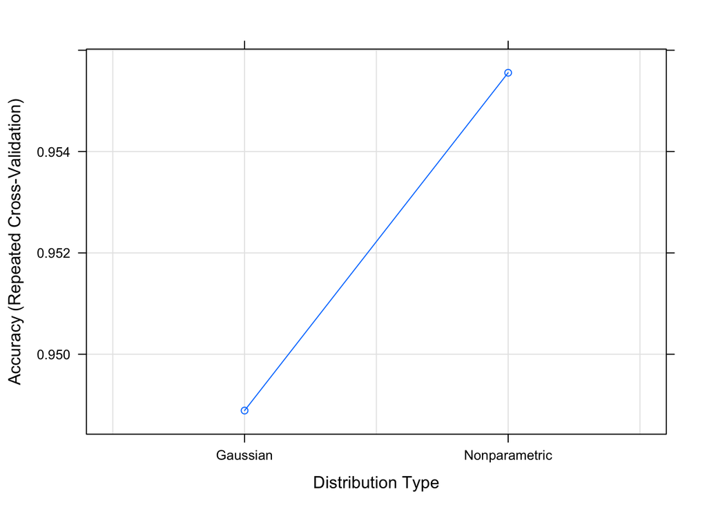

#### Estimate Accuracy by Leave One Out Cross Validation method

In Leave One Out Cross Validation (LOOCV), a data instance is left out and a model constructed on all other data instances in the training set. This is repeated for all data instances. The following example demonstrates LOOCV to estimate Naive Bayes on the iris dataset.

unifreqDF data: When LOOVC is applied to our dataset, unifreqDF, as is, time to finish is over 1 hour, so would need to reduce the sample size for this demo.

##### EXAMPLE 5: LOOCV - returns accuracy 0.960, 0.953, 0.960

input: The final values used with for the model were fL= 0, usekernel= TRUE and adjust= 1 output: Accuracy = 0.960, 0.953, 0.960 model: naive bayes Predicted attribute: class of iris plant

```
## Naive Bayes
##
## 150 samples
##   4 predictor
##   3 classes: 'setosa', 'versicolor', 'virginica'
##
## No pre-processing
## Resampling: Leave-One-Out Cross-Validation
## Summary of sample sizes: 149, 149, 149, 149, 149, 149, ...
## Resampling results across tuning parameters:
##
##   usekernel  Accuracy   Kappa
##   FALSE      0.9533333  0.93
##    TRUE      0.9600000  0.94
##
## Tuning parameter 'fL' was held constant at a value of 0
## Tuning
##  parameter 'adjust' was held constant at a value of 1
## Accuracy was used to select the optimal model using the largest value.
## The final values used for the model were fL = 0, usekernel = TRUE and adjust
##  = 1.
```

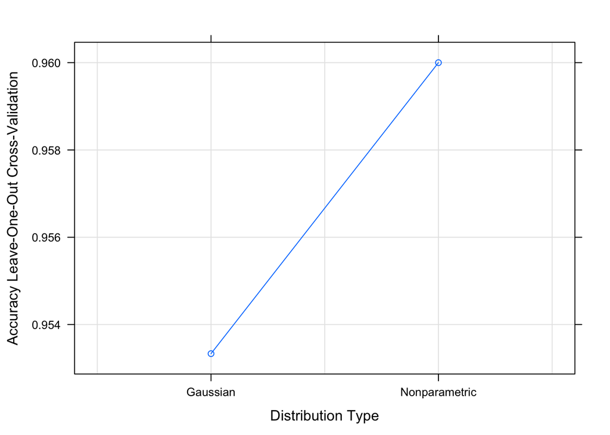

```r
#note: 'include=FALSE' is applied to areas of code not of immediate relevance to a summary presentation.  Scripts may be accessed through the appendix as open sourced material.
```